# Impact of dividend policy on stock prices

VAISHNAVI GUPTA (232PGF029)

2024-04-12

Loading all datasets

```r
library(reshape2)
library(tidyverse)
library(writexl)
library(readxl)

nifty_pat <- read_excel("C:/Users/Vaishnavi/Desktop/nifty data/nifty pat.xlsx")
View(nifty_pat)

nifty_eps <- read_excel("C:/Users/Vaishnavi/Desktop/nifty data/nifty eps.xlsx")
View(nifty_eps)

nifty_equity_capital <- read_excel("C:/Users/Vaishnavi/Desktop/nifty data/nifty equity_capital.xlsx")
View(nifty_equity_capital)

nifty_share_count <- read_excel("C:/Users/Vaishnavi/Desktop/nifty data/nifty share_count.xlsx")
View(nifty_share_count)

nifty_dividend_paid <- read_excel("C:/Users/Vaishnavi/Desktop/nifty data/nifty dividend_paid.xlsx")
View(nifty_dividend_paid)

nifty_mps <- read_excel("C:/Users/Vaishnavi/Desktop/nifty data/nifty mps.xlsx")
View(nifty_mps)
```

Loading all singel variable wide panel datasets and making them long panel one by one.

```r
glimpse(nifty_pat)
```

```
## Rows: 50
## Columns: 12
## $ company <chr> "Adani Enterprises Ltd.", "Adani Ports & Special Economic Zone…
## $ `2013`  <dbl> 545.02, 1754.18, 309.11, 1050.00, 5179.43, 3043.57, 591.31, 50…
## $ `2014`  <dbl> -152.53, 2016.17, 330.72, 1169.06, 6217.67, 3247.92, 719.01, 8…
## $ `2015`  <dbl> 433.02, 2183.14, 346.60, 1327.40, 7357.82, 2813.74, 897.87, 12…
## $ `2016`  <dbl> 520.11, 2964.50, 333.95, 1622.81, 8223.66, 3929.67, 1278.52, 1…
## $ `2017`  <dbl> 221.64, 3100.61, 285.15, 1801.72, 3679.28, 3827.56, 1836.55, 7…
## $ `2018`  <dbl> 197.03, 2408.10, 233.20, 1894.80, 275.68, 4068.10, 2484.51, 14…
## $ `2019`  <dbl> 487.24, 2637.72, 302.80, 2132.17, 4676.61, 4675.18, 3890.34, 3…
## $ `2020`  <dbl> 698.89, 1934.25, 470.20, 2653.95, 1627.22, 5099.98, 4881.12, 6…
## $ `2021`  <dbl> 368.81, 1927.93, 105.00, 3051.80, 6588.50, 4554.59, 3955.51, 1…
## $ `2022`  <dbl> 720.70, 147.56, 665.20, 3134.71, 13025.48, 5018.87, 6350.49, 4…
## $ `2023`  <dbl> 1622.73, -479.43, 1084.80, 4100.18, 9579.68, 5627.60, 10289.74…
```

```r
names(nifty_pat)
```

```
##  [1] "company" "2013"    "2014"    "2015"    "2016"    "2017"    "2018"
##  [8] "2019"    "2020"    "2021"    "2022"    "2023"
```

```r
pat<-pivot_longer(nifty_pat,
                  cols=2:12,
                  names_to="year",
                  values_to="PAT")
View(pat)
glimpse(pat)
```

```
## Rows: 550
## Columns: 3
## $ company <chr> "Adani Enterprises Ltd.", "Adani Enterprises Ltd.", "Adani Ent…
## $ year    <chr> "2013", "2014", "2015", "2016", "2017", "2018", "2019", "2020"…
## $ PAT     <dbl> 545.02, -152.53, 433.02, 520.11, 221.64, 197.03, 487.24, 698.8…
```

```r
glimpse(nifty_mps)
```

```
## Rows: 50
## Columns: 12
## $ company <chr> "Adani Enterprises Ltd.", "Adani Ports & Special Economic Zone…
## $ `2013`  <dbl> 202.20, 138.70, 838.90, 491.73, 260.14, 1799.55, 114.81, 77.16…
## $ `2014`  <dbl> 368.00, 187.45, 916.45, 547.95, 292.10, 2083.60, 179.10, 78.81…
## $ `2015`  <dbl> 615.35, 308.20, 1369.20, 811.30, 560.20, 2016.60, 410.85, 141.…
## $ `2016`  <dbl> 73.80, 247.70, 1329.30, 868.40, 444.15, 2405.95, 692.41, 171.1…
## $ `2017`  <dbl> 108.55, 339.60, 1165.15, 1073.50, 490.80, 2805.45, 1171.10, 40…
## $ `2018`  <dbl> 156.40, 354.10, 1064.65, 1120.40, 510.50, 2744.70, 1767.55, 51…
## $ `2019`  <dbl> 146.75, 378.15, 1227.60, 1492.70, 777.25, 2911.10, 3025.00, 70…
## $ `2020`  <dbl> 137.60, 251.30, 1139.05, 1666.50, 379.00, 2022.35, 2215.80, 45…
## $ `2021`  <dbl> 1031.15, 702.40, 2902.65, 2537.40, 697.45, 3670.60, 5149.85, 9…
## $ `2022`  <dbl> 2014.75, 774.20, 4516.10, 3079.95, 761.15, 3653.00, 7259.95, 1…
## $ `2023`  <dbl> 1750.45, 631.90, 4310.90, 2761.65, 858.50, 3884.75, 5616.75, 1…
```

```r
names(nifty_mps)
```

```
##  [1] "company" "2013"    "2014"    "2015"    "2016"    "2017"    "2018"
##  [8] "2019"    "2020"    "2021"    "2022"    "2023"
```

```r
mps<-pivot_longer(nifty_mps,
                  cols=2:12,
                  names_to="year",
                  values_to="MPS")
View(mps)
glimpse(mps)
```

```
## Rows: 550
## Columns: 3
## $ company <chr> "Adani Enterprises Ltd.", "Adani Enterprises Ltd.", "Adani Ent…
## $ year    <chr> "2013", "2014", "2015", "2016", "2017", "2018", "2019", "2020"…
## $ MPS     <dbl> 202.20, 368.00, 615.35, 73.80, 108.55, 156.40, 146.75, 137.60,…
```

```r
glimpse(nifty_dividend_paid)
```

```
## Rows: 50
## Columns: 12
## $ company <chr> "Adani Enterprises Ltd.", "Adani Ports & Special Economic Zone…
## $ `2013`  <dbl> 153.97, 200.34, 78.69, 441.23, 987.23, 1302.15, 74.67, 23.87, …
## $ `2014`  <dbl> 153.97, 213.67, 80.00, 508.37, 1101.12, 1446.84, 80.23, 27.85,…
## $ `2015`  <dbl> 153.97, 227.71, 80.00, 585.12, 1308.96, 1446.84, 90.27, 27.85,…
## $ `2016`  <dbl> 197.96, 455.51, 196.75, 623.48, 2.81, 2893.68, 140.57, 27.85, …
## $ `2017`  <dbl> NA, NA, NA, 762.56, 1407.43, 144.68, NA, NA, 5640.06, 543.60, …
## $ `2018`  <dbl> 43.99, 269.22, 83.47, 987.98, 1405.28, 1591.52, 197.13, 27.85,…
## $ `2019`  <dbl> 43.99, 414.19, 69.50, 853.68, NA, 1736.20, 230.36, 27.85, 3904…
## $ `2020`  <dbl> 153.97, 691.58, 128.70, 1740.95, 288.86, 5208.60, 946.42, 119.…
## $ `2021`  <dbl> NA, NA, 38.20, 465.23, NA, NA, NA, NA, 4555.43, 1091.10, 2839.…
## $ `2022`  <dbl> 109.98, 1020.88, 43.10, 1740.95, NA, 4051.14, 602.34, 47.74, 1…
## $ `2023`  <dbl> 114.00, 1056.19, 255.20, 1908.86, 307.15, 4051.14, 1207.32, 63…
```

```r
names(nifty_dividend_paid)
```

```
##  [1] "company" "2013"    "2014"    "2015"    "2016"    "2017"    "2018"
##  [8] "2019"    "2020"    "2021"    "2022"    "2023"
```

```r
dividend<-pivot_longer(nifty_dividend_paid,
                  cols=2:12,
                  names_to="year",
                  values_to="div_paid")
View(dividend)
glimpse(dividend)
```

```
## Rows: 550
## Columns: 3
## $ company  <chr> "Adani Enterprises Ltd.", "Adani Enterprises Ltd.", "Adani En…
## $ year     <chr> "2013", "2014", "2015", "2016", "2017", "2018", "2019", "2020…
## $ div_paid <dbl> 153.97, 153.97, 153.97, 197.96, NA, 43.99, 43.99, 153.97, NA,…
```

```r
glimpse(nifty_eps)
```

```
## Rows: 50
## Columns: 12
## $ company <chr> "Adani Enterprises Ltd.", "Adani Ports & Special Economic Zone…
## $ `2013`  <dbl> 4.44, 7.99, 21.32, 109.62, 97.65, 103.62, 84.60, 4.77, 20.69, …
## $ `2014`  <dbl> -2.29, 9.18, 23.97, 12.26, 126.28, 108.04, 118.53, 4.80, 53.40…
## $ `2015`  <dbl> 3.68, 10.39, 23.79, 13.85, 29.99, 107.59, 142.33, 6.85, 60.02,…
## $ `2016`  <dbl> 4.70, 14.30, 26.09, 17.45, 31.45, 134.43, 225.94, 10.24, 97.99…
## $ `2017`  <dbl> 2.13, 15.07, 20.48, 18.73, 14.56, 129.91, 32.41, 4.38, 54.89, …
## $ `2018`  <dbl> 1.07, 13.83, 15.92, 19.16, 13.63, 129.25, 36.97, 8.62, 31.98, …
## $ `2019`  <dbl> 2.08, 11.95, 20.82, 22.39, -0.38, 152.03, 57.94, 19.84, 29.08,…
## $ `2020`  <dbl> 3.59, 9.48, 36.69, 27.95, 0.15, 176.52, 77.62, 41.93, 9.13, -4…
## $ `2021`  <dbl> 4.52, 9.49, -2.01, 31.58, 17.38, 157.53, 62.99, 11.24, 48.02, …
## $ `2022`  <dbl> 6.27, 0.76, 40.30, 32.78, 34.54, 172.83, 91.55, 24.61, 46.92, …
## $ `2023`  <dbl> 14.79, -2.06, 75.70, 42.36, 18.55, 195.40, 152.09, 4.60, 14.55…
```

```r
names(nifty_eps)
```

```
##  [1] "company" "2013"    "2014"    "2015"    "2016"    "2017"    "2018"
##  [8] "2019"    "2020"    "2021"    "2022"    "2023"
```

```r
eps<-pivot_longer(nifty_eps,
                       cols=2:12,
                       names_to="year",
                       values_to="EPS")
View(eps)
glimpse(eps)
```

```
## Rows: 550
## Columns: 3
## $ company <chr> "Adani Enterprises Ltd.", "Adani Enterprises Ltd.", "Adani Ent…
## $ year    <chr> "2013", "2014", "2015", "2016", "2017", "2018", "2019", "2020"…
## $ EPS     <dbl> 4.44, -2.29, 3.68, 4.70, 2.13, 1.07, 2.08, 3.59, 4.52, 6.27, 1…
```

```r
glimpse(nifty_equity_capital)
```

```
## Rows: 50
## Columns: 12
## $ company <chr> "Adani Enterprises Ltd.", "Adani Ports & Special Economic Zone…
## $ `2013`  <dbl> 109.98, 400.68, 69.56, 95.92, 467.95, 289.37, 49.54, 79.56, 72…
## $ `2014`  <dbl> 109.98, 414.01, 69.56, 95.92, 469.84, 289.37, 49.75, 79.56, 72…
## $ `2015`  <dbl> 109.98, 414.01, 69.56, 95.92, 474.10, 289.37, 50.00, 79.56, 72…
## $ `2016`  <dbl> 109.98, 414.19, 69.56, 95.92, 476.57, 289.37, 53.55, 79.57, 65…
## $ `2017`  <dbl> 109.98, 414.19, 69.56, 95.92, 479.01, 289.37, 109.37, 79.57, 1…
## $ `2018`  <dbl> 109.98, 414.19, 69.56, 95.92, 513.31, 289.37, 115.03, 79.57, 1…
## $ `2019`  <dbl> 109.98, 414.19, 69.60, 95.92, 514.33, 289.37, 115.37, 79.57, 1…
## $ `2020`  <dbl> 109.98, 406.35, 69.60, 95.92, 564.34, 289.37, 119.99, 79.57, 1…
## $ `2021`  <dbl> 109.98, 406.35, 71.90, 95.92, 612.75, 289.37, 120.32, 79.57, 2…
## $ `2022`  <dbl> 109.98, 422.47, 71.90, 95.92, 613.95, 289.37, 120.66, 79.57, 2…
## $ `2023`  <dbl> 114.00, 432.03, 71.90, 95.92, 615.37, 282.96, 120.89, 159.26, …
```

```r
names(nifty_equity_capital)
```

```
##  [1] "company" "2013"    "2014"    "2015"    "2016"    "2017"    "2018"
##  [8] "2019"    "2020"    "2021"    "2022"    "2023"
```

```r
equity<-pivot_longer(nifty_equity_capital,
                  cols=2:12,
                  names_to="year",
                  values_to="equity_capital")
View(equity)
glimpse(equity)
```

```
## Rows: 550
## Columns: 3
## $ company        <chr> "Adani Enterprises Ltd.", "Adani Enterprises Ltd.", "Ad…
## $ year           <chr> "2013", "2014", "2015", "2016", "2017", "2018", "2019",…
## $ equity_capital <dbl> 109.98, 109.98, 109.98, 109.98, 109.98, 109.98, 109.98,…
```

```r
glimpse(nifty_share_count)
```

```
## Rows: 50
## Columns: 12
## $ company <chr> "Adani Enterprises Ltd.", "Adani Ports & Special Economic Zone…
## $ `2013`  <dbl> 1099810083, 2003394100, 139125159, 95919779, 467954468, 289367…
## $ `2014`  <dbl> 1099810083, 2070051620, 139125159, 959197790, 469844553, 28936…
## $ `2015`  <dbl> 1099810083, 2070051620, 139125159, 959197790, 2370522199, 2893…
## $ `2016`  <dbl> 1099810083, 2070951761, 139125159, 959197790, 2382831826, 2893…
## $ `2017`  <dbl> 1099810083, 2070951761, 139125159, 959197790, 2395036109, 2893…
## $ `2018`  <dbl> 1099810083, 2070951761, 139125159, 959197790, 2566538936, 2893…
## $ `2019`  <dbl> 1099810083, 2070951761, 139125159, 959197790, 2571644871, 2893…
## $ `2020`  <dbl> 1099810083, 2031751761, 139125159, 959197790, 2821677934, 2893…
## $ `2021`  <dbl> 1099810083, 2031751761, 143784657, 959197790, 3063748652, 2893…
## $ `2022`  <dbl> 1099810083, 2112373230, 143784657, 959197790, 3069747836, 2893…
## $ `2023`  <dbl> 1140001121, 2160138945, 143784657, 959197790, 3076852012, 2829…
```

```r
names(nifty_share_count)
```

```
##  [1] "company" "2013"    "2014"    "2015"    "2016"    "2017"    "2018"
##  [8] "2019"    "2020"    "2021"    "2022"    "2023"
```

```r
share_no<-pivot_longer(nifty_share_count,
                       cols=2:12,
                       names_to="year",
                       values_to="share_count")
View(share_no)
glimpse(share_no)
```

```
## Rows: 550
## Columns: 3
## $ company     <chr> "Adani Enterprises Ltd.", "Adani Enterprises Ltd.", "Adani…
## $ year        <chr> "2013", "2014", "2015", "2016", "2017", "2018", "2019", "2…
## $ share_count <dbl> 1099810083, 1099810083, 1099810083, 1099810083, 1099810083…
```

single panel long datasets are created (pat,mps,eps,share_no,equity,dividend) we are merging all dataframes.

```r
merged_df1<-merge(pat,dividend,by = c("company","year"))
View(merged_df1)

merged_df2<-merge(merged_df1,mps,by = c("company","year"))
View(merged_df2)

merged_df3<-merge(merged_df2,eps,by = c("company","year"))
View(merged_df3)

merged_df4<-merge(merged_df3,equity,by = c("company","year"))
View(merged_df4)

merged_df5<-merge(merged_df4,share_no,by = c("company","year"))
View(merged_df5)

merge_final_nifty<-merged_df5
```

exporting this final merged file

```r
write_xlsx(merge_final_nifty,"merged_all_nifty.xlsx")

merged_all_nifty <- read_excel("C:/Users/Vaishnavi/Desktop/nifty data/merged_all_nifty.xlsx")
View(merged_all_nifty)
```

replacing missing values with 0 in data.

```r
names(merged_all_nifty)
```

```
## [1] "company"        "year"           "PAT"            "div_paid"
## [5] "MPS"            "EPS"            "equity_capital" "share_count"
```

```r
df11<-mutate(merged_all_nifty,PAT=replace_na(PAT,0))
df12<-mutate(df11,div_paid=replace_na(div_paid,0))
df13<-mutate(df12,EPS=replace_na(EPS,0))
df14<-mutate(df13,MPS=replace_na(MPS,0))
df15<-mutate(df14,equity_capital=replace_na(equity_capital,0))
df16<-mutate(df15,share_count=replace_na(share_count,0))
View(df16)
```

Creating the relevant variables

```r
#TOTAL DIVIDEND
df21<-mutate(df16,total_dividend_Rs=div_paid*10000000)
View(df21)

#DPS
df22<-mutate(df21,DPS=total_dividend_Rs/share_count)
View(df22)
glimpse(df22)
```

```
## Rows: 550
## Columns: 10
## $ company           <chr> "Adani Enterprises Ltd.", "Adani Enterprises Ltd.", …
## $ year              <chr> "2013", "2014", "2015", "2016", "2017", "2018", "201…
## $ PAT               <dbl> 545.02, -152.53, 433.02, 520.11, 221.64, 197.03, 487…
## $ div_paid          <dbl> 153.97, 153.97, 153.97, 197.96, 0.00, 43.99, 43.99, …
## $ MPS               <dbl> 202.20, 368.00, 615.35, 73.80, 108.55, 156.40, 146.7…
## $ EPS               <dbl> 4.44, -2.29, 3.68, 4.70, 2.13, 1.07, 2.08, 3.59, 4.5…
## $ equity_capital    <dbl> 109.98, 109.98, 109.98, 109.98, 109.98, 109.98, 109.…
## $ share_count       <dbl> 1099810083, 1099810083, 1099810083, 1099810083, 1099…
## $ total_dividend_Rs <dbl> 1539700000, 1539700000, 1539700000, 1979600000, 0, 4…
## $ DPS               <dbl> 1.3999690, 1.3999690, 1.3999690, 1.7999471, 0.000000…
```

```r
##replacing NaN and Inf with 0
df23<-mutate(df22,DPS1=replace(DPS,is.nan(DPS)|is.infinite(DPS),0))
View(df23)
##changing to float type with
##format(df,number_scientific, scientific = FALSE, digits = 2)
df24<-mutate(df23,DPS1=format(DPS1,scientific=FALSE,digits=3))
View(df24)

#RR
df25<-mutate(df24,RR=(PAT-div_paid)/PAT)
View(df25)
df26<-mutate(df25,RR=replace(RR,is.nan(RR)|is.infinite(RR),0))
View(df26)
#DY
df27<-mutate(df26,DY=DPS/MPS)
df28<-mutate(df27,DY1=replace(DY,is.nan(DY)|is.infinite(DY),0))
View(df28)
df29<-mutate(df28,DY1=format(DY1,scientific=FALSE,digits=3))
View(df29)
#ROE
df210<-mutate(df29,ROE=PAT/equity_capital)
df211<-mutate(df210,ROE=replace(ROE,is.nan(ROE)|is.infinite(ROE),0))
View(df211)
```

Keeping relevant variables

```r
names(df211)
```

```
##  [1] "company"           "year"              "PAT"
##  [4] "div_paid"          "MPS"               "EPS"
##  [7] "equity_capital"    "share_count"       "total_dividend_Rs"
## [10] "DPS"               "DPS1"              "RR"
## [13] "DY"                "DY1"               "ROE"
```

```r
final_df<-select(df211,company,year,MPS,PAT,EPS,DY1,DPS1,RR,ROE)
final_df<-mutate(final_df,DY=DY1,DPS=DPS1)
final_df<-select(final_df,-c(DY1,DPS1))
glimpse(final_df)
```

```
## Rows: 550
## Columns: 9
## $ company <chr> "Adani Enterprises Ltd.", "Adani Enterprises Ltd.", "Adani Ent…
## $ year    <chr> "2013", "2014", "2015", "2016", "2017", "2018", "2019", "2020"…
## $ MPS     <dbl> 202.20, 368.00, 615.35, 73.80, 108.55, 156.40, 146.75, 137.60,…
## $ PAT     <dbl> 545.02, -152.53, 433.02, 520.11, 221.64, 197.03, 487.24, 698.8…
## $ EPS     <dbl> 4.44, -2.29, 3.68, 4.70, 2.13, 1.07, 2.08, 3.59, 4.52, 6.27, 1…
## $ RR      <dbl> 0.7174966, 2.0094408, 0.6444275, 0.6193882, 1.0000000, 0.77673…
## $ ROE     <dbl> 4.9556283, -1.3868885, 3.9372613, 4.7291326, 2.0152755, 1.7915…
## $ DY      <chr> " 0.006923684", " 0.003804264", " 0.002275078", " 0.024389527"…
## $ DPS     <chr> "  1.39997", "  1.39997", "  1.39997", "  1.79995", "  0.00000…
```

```r
final_df1<-mutate(final_df,DY1=as.numeric(DY),DPS1=as.numeric(DPS))
View(final_df1)
glimpse(final_df1)
```

```
## Rows: 550
## Columns: 11
## $ company <chr> "Adani Enterprises Ltd.", "Adani Enterprises Ltd.", "Adani Ent…
## $ year    <chr> "2013", "2014", "2015", "2016", "2017", "2018", "2019", "2020"…
## $ MPS     <dbl> 202.20, 368.00, 615.35, 73.80, 108.55, 156.40, 146.75, 137.60,…
## $ PAT     <dbl> 545.02, -152.53, 433.02, 520.11, 221.64, 197.03, 487.24, 698.8…
## $ EPS     <dbl> 4.44, -2.29, 3.68, 4.70, 2.13, 1.07, 2.08, 3.59, 4.52, 6.27, 1…
## $ RR      <dbl> 0.7174966, 2.0094408, 0.6444275, 0.6193882, 1.0000000, 0.77673…
## $ ROE     <dbl> 4.9556283, -1.3868885, 3.9372613, 4.7291326, 2.0152755, 1.7915…
## $ DY      <chr> " 0.006923684", " 0.003804264", " 0.002275078", " 0.024389527"…
## $ DPS     <chr> "  1.39997", "  1.39997", "  1.39997", "  1.79995", "  0.00000…
## $ DY1     <dbl> 0.006923684, 0.003804264, 0.002275078, 0.024389527, 0.00000000…
## $ DPS1    <dbl> 1.39997, 1.39997, 1.39997, 1.79995, 0.00000, 0.39998, 0.39998,…
```

```r
final_df<-select(final_df1,-c(DY,DPS))
View(final_df)
glimpse(final_df)
```

```
## Rows: 550
## Columns: 9
## $ company <chr> "Adani Enterprises Ltd.", "Adani Enterprises Ltd.", "Adani Ent…
## $ year    <chr> "2013", "2014", "2015", "2016", "2017", "2018", "2019", "2020"…
## $ MPS     <dbl> 202.20, 368.00, 615.35, 73.80, 108.55, 156.40, 146.75, 137.60,…
## $ PAT     <dbl> 545.02, -152.53, 433.02, 520.11, 221.64, 197.03, 487.24, 698.8…
## $ EPS     <dbl> 4.44, -2.29, 3.68, 4.70, 2.13, 1.07, 2.08, 3.59, 4.52, 6.27, 1…
## $ RR      <dbl> 0.7174966, 2.0094408, 0.6444275, 0.6193882, 1.0000000, 0.77673…
## $ ROE     <dbl> 4.9556283, -1.3868885, 3.9372613, 4.7291326, 2.0152755, 1.7915…
## $ DY1     <dbl> 0.006923684, 0.003804264, 0.002275078, 0.024389527, 0.00000000…
## $ DPS1    <dbl> 1.39997, 1.39997, 1.39997, 1.79995, 0.00000, 0.39998, 0.39998,…
```

Winsorizing data to adjust for outliers at 5% at the extremes. we create two final datasets, one winsorized and the other not. (don’t use this winsorized data with dummy regression)

```r
library(DescTools)
final_df$MPS1<- Winsorize(final_df$MPS, minval = NULL, maxval = NULL, probs = c(0.05, 0.95),na.rm = FALSE,type=7)

final_df$PAT1<- Winsorize(final_df$PAT, minval = NULL, maxval = NULL, probs = c(0.05, 0.95),na.rm = FALSE,type=7)

final_df$EPS1<- Winsorize(final_df$EPS, minval = NULL, maxval = NULL, probs = c(0.05, 0.95),na.rm = FALSE,type=7)

final_df$RR1<- Winsorize(final_df$RR, minval = NULL, maxval = NULL, probs = c(0.05, 0.95),na.rm = FALSE,type=7)

final_df$DY2<- Winsorize(final_df$DY1, minval = NULL, maxval = NULL, probs = c(0.05, 0.95),na.rm = FALSE,type=7)

final_df$DPS2<- Winsorize(final_df$DPS1, minval = NULL, maxval = NULL, probs = c(0.05, 0.95),na.rm = FALSE,type=7)

final_df$ROE1<- Winsorize(final_df$ROE, minval = NULL, maxval = NULL, probs = c(0.05, 0.95),na.rm = FALSE,type=7)

View(final_df)
names(final_df)
```

```
##  [1] "company" "year"    "MPS"     "PAT"     "EPS"     "RR"      "ROE"
##  [8] "DY1"     "DPS1"    "MPS1"    "PAT1"    "EPS1"    "RR1"     "DY2"
## [15] "DPS2"    "ROE1"
```

```r
win_final_df<-select(final_df,-c(MPS,PAT,EPS,RR,ROE,DY1,DPS1))
View(win_final_df)
```

exporting these final compiled file

```r
write_xlsx(final_df,"final_df_nifty.xlsx")
write_xlsx(win_final_df,"win_final_df_nifty.xlsx")

final_df_nifty <- read_excel("C:/Users/Vaishnavi/Desktop/nifty data/final_df_nifty.xlsx")
View(final_df_nifty)

win_final_df_nifty <- read_excel("E:/MODULE 1 R/win_final_df_nifty.xlsx")
View(win_final_df_nifty)
```

Descriptive statistics

```r
library(tidyverse)
library(plm)
```

```r
library(gplots)
glimpse(final_df_nifty)
```

```
## Rows: 550
## Columns: 9
## $ company <chr> "Adani Enterprises Ltd.", "Adani Enterprises Ltd.", "Adani Ent…
## $ year    <chr> "2013", "2014", "2015", "2016", "2017", "2018", "2019", "2020"…
## $ MPS     <dbl> 202.20, 368.00, 615.35, 73.80, 108.55, 156.40, 146.75, 137.60,…
## $ PAT     <dbl> 545.02, -152.53, 433.02, 520.11, 221.64, 197.03, 487.24, 698.8…
## $ EPS     <dbl> 4.44, -2.29, 3.68, 4.70, 2.13, 1.07, 2.08, 3.59, 4.52, 6.27, 1…
## $ RR      <dbl> 0.7174966, 2.0094408, 0.6444275, 0.6193882, 1.0000000, 0.77673…
## $ ROE     <dbl> 4.9556283, -1.3868885, 3.9372613, 4.7291326, 2.0152755, 1.7915…
## $ DY1     <dbl> 0.006923684, 0.003804264, 0.002275078, 0.024389527, 0.00000000…
## $ DPS1    <dbl> 1.39997, 1.39997, 1.39997, 1.79995, 0.00000, 0.39998, 0.39998,…
```

```r
names(final_df_nifty)
```

```
## [1] "company" "year"    "MPS"     "PAT"     "EPS"     "RR"      "ROE"
## [8] "DY1"     "DPS1"
```

```r
dfcov<-select(final_df_nifty,-c(company,year))
var_cov<-cov(dfcov)
var_cov
```

```
##                MPS           PAT           EPS            RR           ROE
## MPS  1824537.61916  1.137911e+04 50096.1336286  2.851243e+01  1.758875e+04
## PAT    11379.11102  7.279930e+07 48782.9882452 -3.091401e+02  5.165976e+04
## EPS    50096.13363  4.878299e+04  6116.7597107 -1.140988e+00  9.127731e+02
## RR        28.51243 -3.091401e+02    -1.1409885  2.741347e+00 -1.104696e+00
## ROE    17588.74758  5.165976e+04   912.7730748 -1.104696e+00  5.783775e+02
## DY1      -12.34112  5.021714e+01     0.8377369 -4.012965e-03 -2.945355e-02
## DPS1   15355.02277  1.079908e+04  1628.3987116 -4.079521e+00  3.240352e+02
##                DY1          DPS1
## MPS  -12.341118335 15355.0227714
## PAT   50.217142405 10799.0789598
## EPS    0.837736887  1628.3987116
## RR    -0.004012965    -4.0795212
## ROE   -0.029453552   324.0351667
## DY1    0.002018787     0.5049723
## DPS1   0.504972340  1006.7435003
```

```r
#company-wise mean of each variable

mean<-final_df_nifty%>%group_by(company)%>%summarize(mean_MPS=mean(MPS),mean_EPS=mean(EPS),
                                                     mean_RR=mean(RR),mean_PAT=mean(PAT),
                                                     mean_ROE=mean(ROE),mean_DPS=mean(DPS1),
                                                     mean_DY=mean(DY1))
mean
```

```
## # A tibble: 50 × 8
##    company          mean_MPS mean_EPS mean_RR mean_PAT mean_ROE mean_DPS mean_DY
##    <chr>               <dbl>    <dbl>   <dbl>    <dbl>    <dbl>    <dbl>   <dbl>
##  1 Adani Enterpris…     600.    4.09    0.930     515.     4.63    0.927 0.00490
##  2 Adani Ports & S…     392.    9.13    0.471    1872.     4.55    1.98  0.00560
##  3 Apollo Hospital…    1889.   27.6     0.742     406.     5.76    6.81  0.00467
##  4 Asian Paints Lt…    1496.   31.6     0.559    2176.    22.7    13.8   0.0152
##  5 Axis Bank Ltd.       548.   34.9     0.433    6039.    11.3     5.77  0.0180
##  6 Bajaj Auto Ltd.     2727.  142.      0.502    4173.    14.5    75.3   0.0293
##  7 Bajaj Finance L…    2509.   98.5     0.910    3380.    32.0    11.6   0.0288
##  8 Bajaj Finserv L…     591.   12.9     0.831     268.     2.95    1.92  0.00805
##  9 Bharat Petroleu…     323.   42.4     0.347    6995.     5.23   25.5   0.0829
## 10 Bharti Airtel L…     422.    0.718   1.10    -4034.    -1.20    2.20  0.00615
## # ℹ 40 more rows
```

```r
#we can do the same with win_final_df_nifty
```

PANEL DATA ANALYSIS: declaring the dataset to be panel Index—name of C.S AND T.S variable

```r
pdata=pdata.frame(final_df_nifty,index=c("company","year")) # include drop.index=TRUE inside to drop indexes from data
names(final_df_nifty)
```

```
## [1] "company" "year"    "MPS"     "PAT"     "EPS"     "RR"      "ROE"
## [8] "DY1"     "DPS1"
```

```r
wpdata=pdata.frame(win_final_df_nifty,index=c("company","year")) # include drop.index=TRUE inside to drop indexes from data
names(win_final_df_nifty)
```

```
## [1] "company" "year"    "MPS1"    "PAT1"    "EPS1"    "RR1"     "DY2"
## [8] "DPS2"    "ROE1"
```

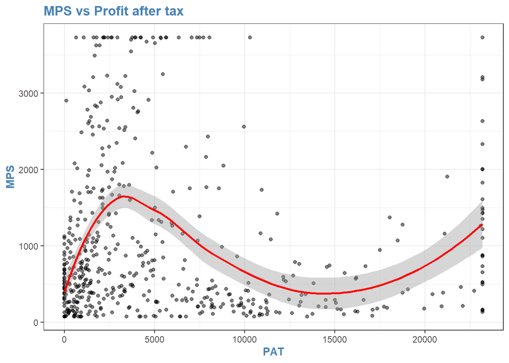

```r
theme_set(theme_bw()+theme(title=element_text(color="steelblue",face="bold")))
#this will set all following plot's themes to a fixed style

plot1<-ggplot(win_final_df_nifty,aes(x=PAT1,y=MPS1))+
       geom_point(aes(),alpha=0.5)+
       geom_smooth(color="red")+
       labs(title="MPS vs Profit after tax ",
            x="PAT",
            y="MPS")
plot1
```

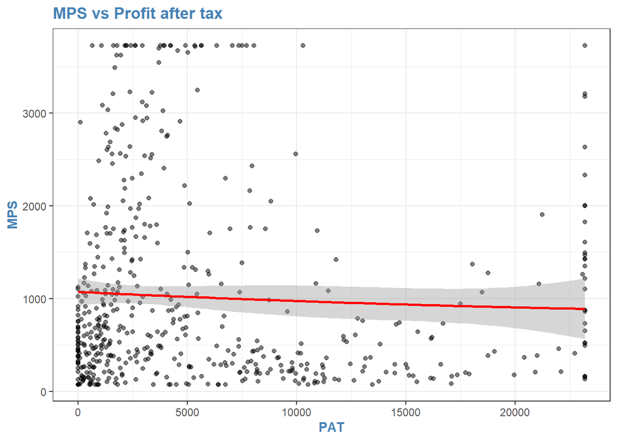

```r
plot2<-ggplot(win_final_df_nifty,aes(x=PAT1,y=MPS1))+
       geom_point(aes(),alpha=0.5)+
       stat_smooth(method="lm",formula=y~x+I(x^2),size=1,color="red")+ #quadratic fitting
       labs(title="MPS vs Profit after tax ",
            x="PAT",
            y="MPS")
plot2
```

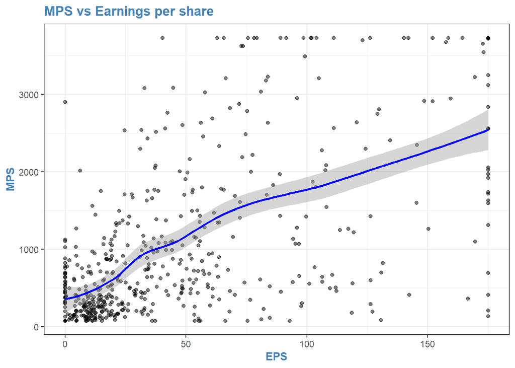

```r
plot3<-ggplot(win_final_df_nifty,aes(x=EPS1,y=MPS1))+
       geom_point(aes(),alpha=0.5)+
       geom_smooth(color="blue")+
       labs(title="MPS vs Earnings per share ",
            x="EPS",
            y="MPS")
plot3
```

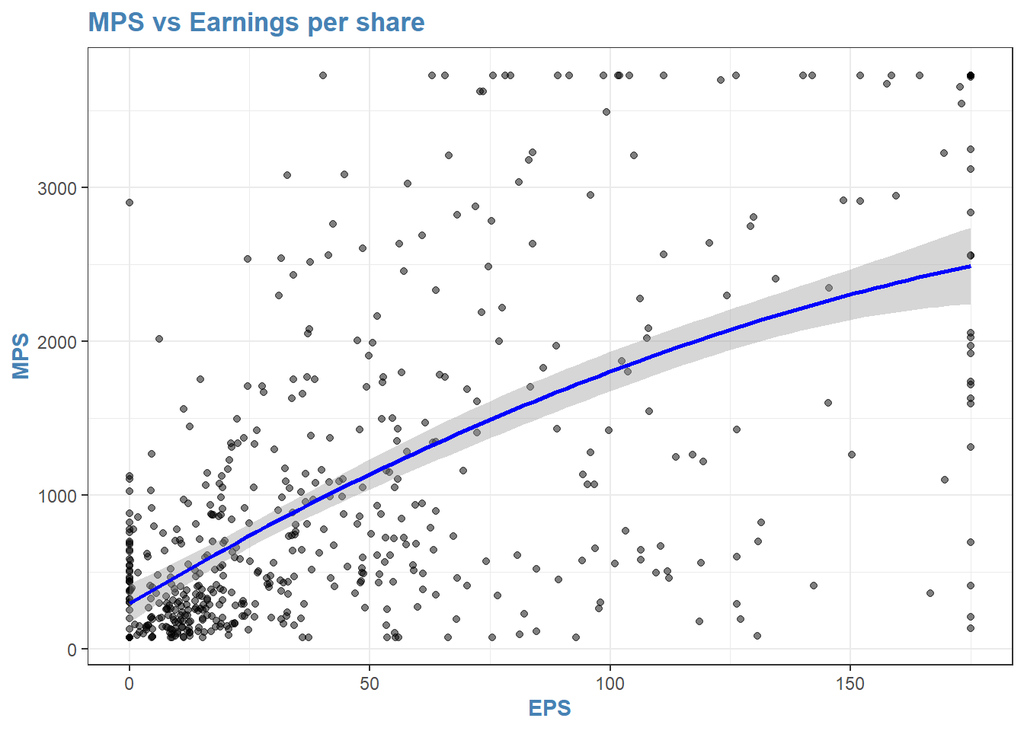

```r
plot4<-ggplot(win_final_df_nifty,aes(x=EPS1,y=MPS1))+
       geom_point(aes(),alpha=0.5)+
       stat_smooth(method="lm",formula=y~x+I(x^2),size=1,color="blue")+
       labs(title="MPS vs Earnings per share ",
            x="EPS",
            y="MPS")
plot4
```

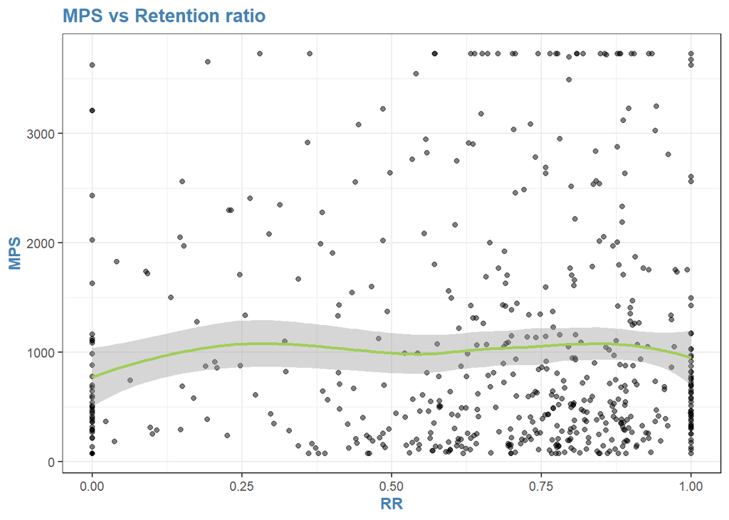

```r
plot5<-ggplot(win_final_df_nifty,aes(x=RR1,y=MPS1))+
       geom_point(aes(),alpha=0.5)+
       geom_smooth(color="darkolivegreen3")+
       labs(title="MPS vs Retention ratio ",
            x="RR",
            y="MPS")
plot5
```

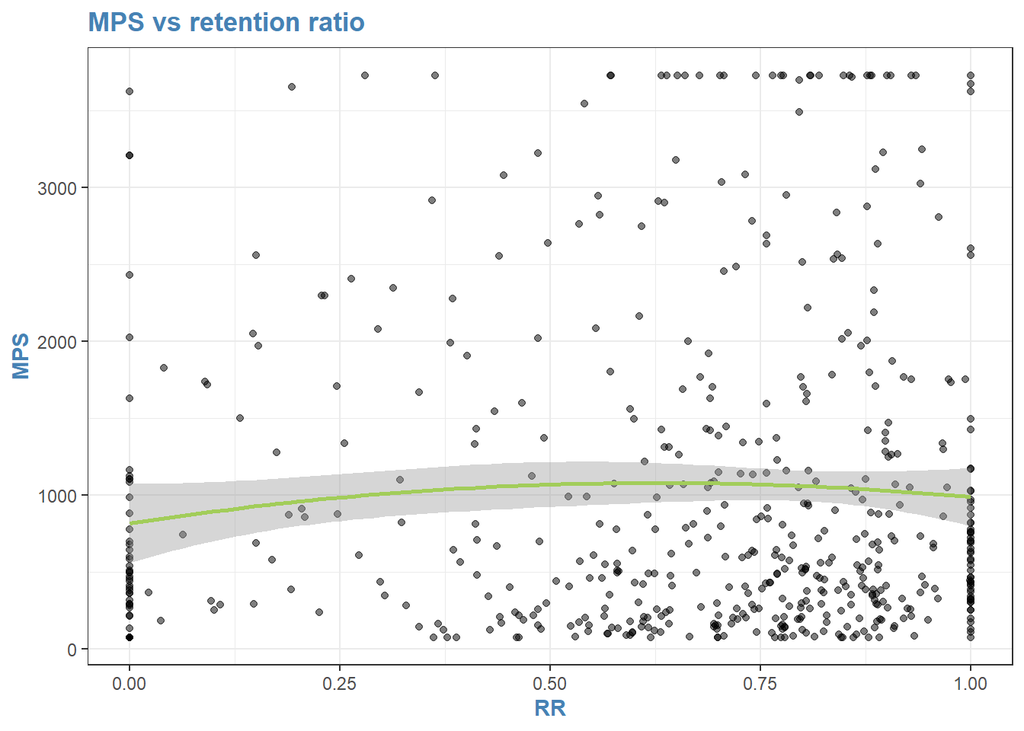

```r
plot6<-ggplot(win_final_df_nifty,aes(x=RR1,y=MPS1))+
       geom_point(aes(),alpha=0.5)+
       stat_smooth(method="lm",formula=y~x+I(x^2),size=1,color="darkolivegreen3")+
       labs(title="MPS vs retention ratio ",
            x="RR",
            y="MPS")
plot6
```

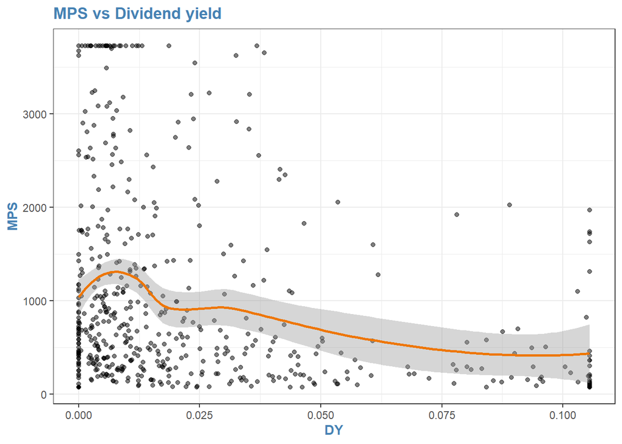

```r
plot7<-ggplot(win_final_df_nifty,aes(x=DY2,y=MPS1))+
       geom_point(aes(),alpha=0.5)+
       geom_smooth(color="darkorange2")+
       labs(title="MPS vs Dividend yield ",
            x="DY",
            y="MPS")
plot7
```

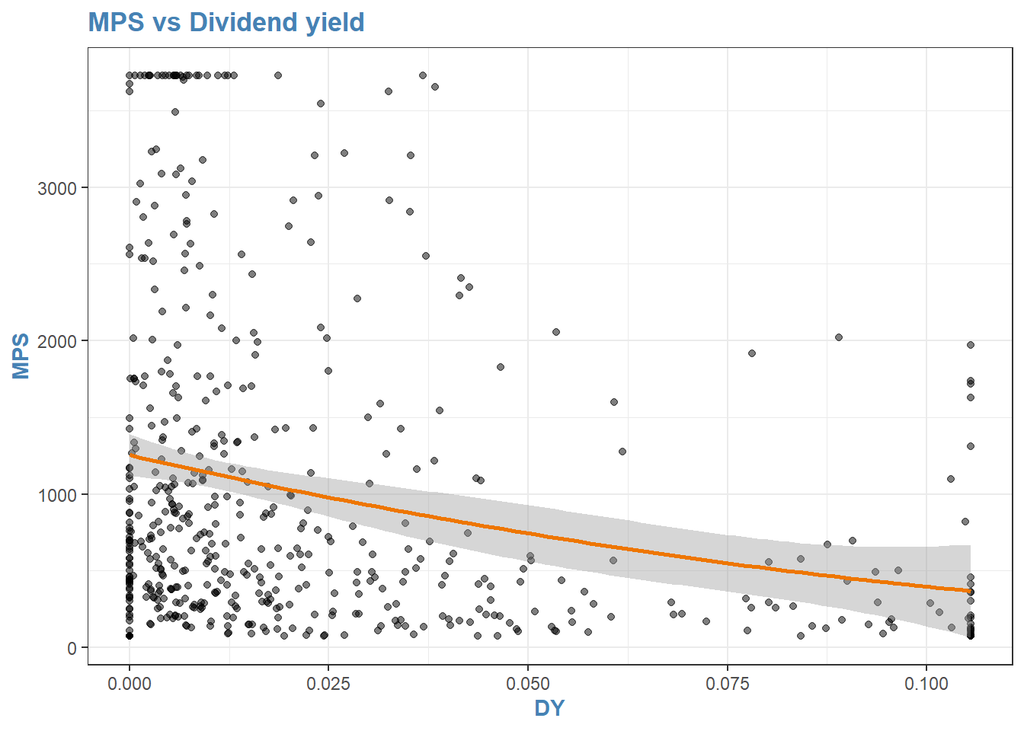

```r
plot8<-ggplot(win_final_df_nifty,aes(x=DY2,y=MPS1))+
       geom_point(aes(),alpha=0.5)+
       stat_smooth(method="lm",formula=y~x+I(x^2),size=1,color="darkorange2")+
       labs(title="MPS vs Dividend yield ",
            x="DY",
            y="MPS")
plot8
```

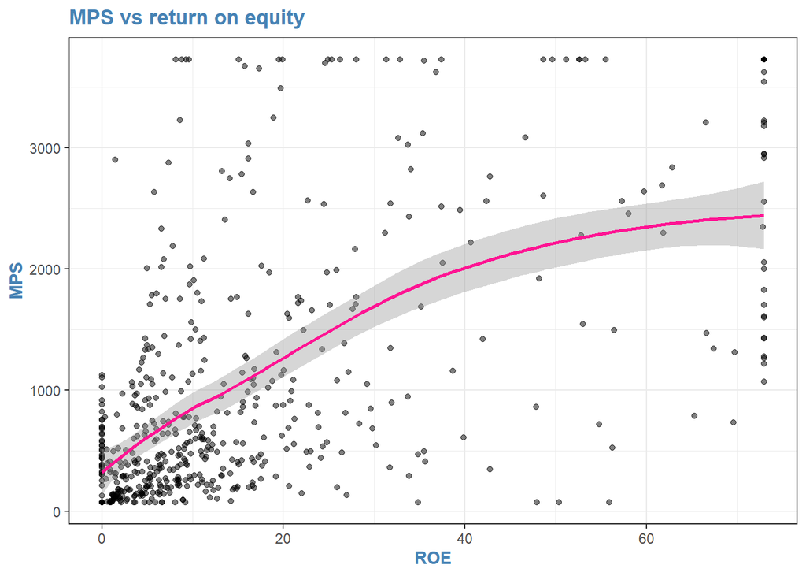

```r
plot9<-ggplot(win_final_df_nifty,aes(x=ROE1,y=MPS1))+
       geom_point(aes(),alpha=0.5)+
       geom_smooth(color="deeppink")+
       labs(title="MPS vs return on equity ",
            x="ROE",
            y="MPS")
plot9
```

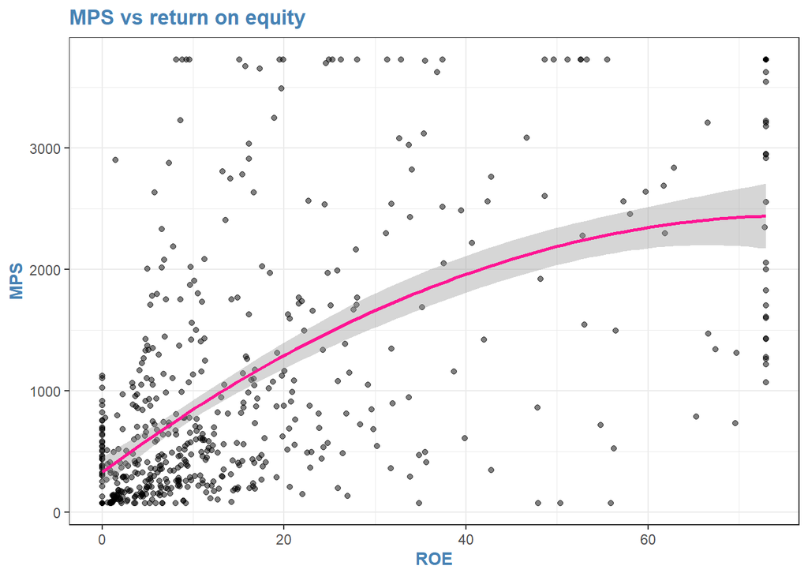

```r
plot10<-ggplot(win_final_df_nifty,aes(x=ROE1,y=MPS1))+
       geom_point(aes(),alpha=0.5)+
       stat_smooth(method="lm",formula=y~x+I(x^2),size=1,color="deeppink")+
       labs(title="MPS vs return on equity ",
            x="ROE",
            y="MPS")
plot10
```

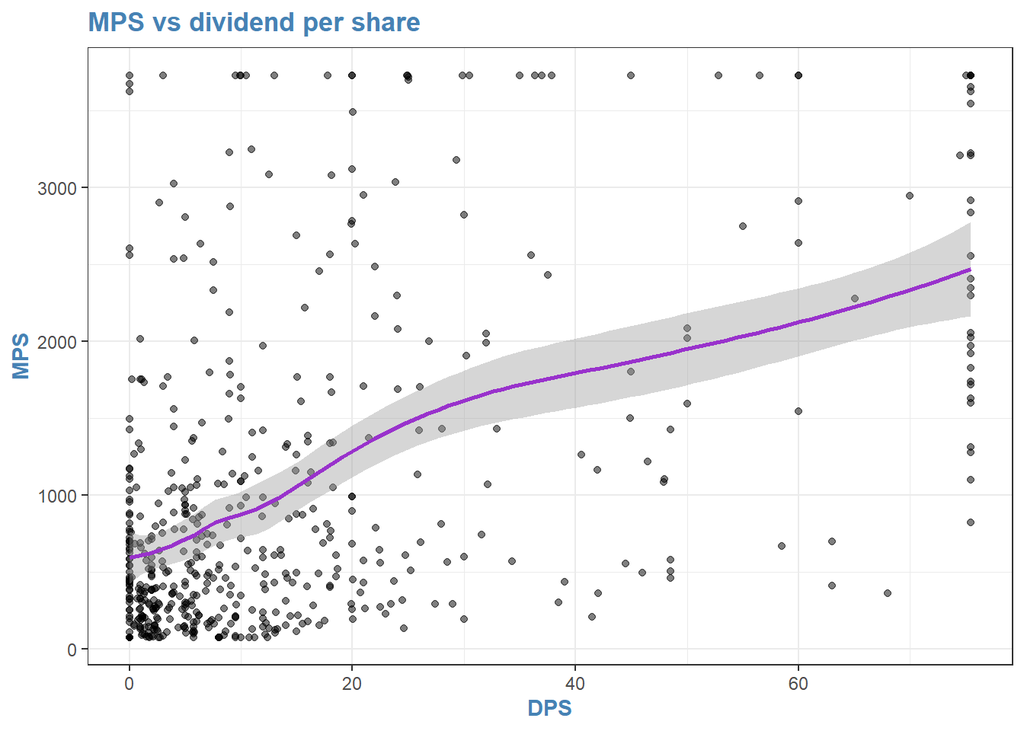

```r
plot11<-ggplot(win_final_df_nifty,aes(x=DPS2,y=MPS1))+
       geom_point(aes(),alpha=0.5)+
       geom_smooth(color="darkorchid")+
       labs(title="MPS vs dividend per share ",
            x="DPS",
            y="MPS")
plot11
```

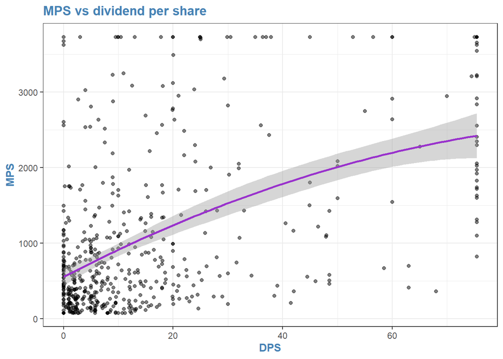

```r
plot12<-ggplot(win_final_df_nifty,aes(x=DPS2,y=MPS1))+
       geom_point(aes(),alpha=0.5)+
       stat_smooth(method="lm",formula=y~x+I(x^2),size=1,color="darkorchid")+
       labs(title="MPS vs dividend per share ",
            x="DPS",
            y="MPS")
plot12
```

we run all models with the winsorized data Running a pooled regression model

here, p value of F statistic is less than 5% which implies that our model is significant. all variables with *** are very significant RR is not significant

```r
pooled_model=plm(MPS1~PAT1+EPS1+RR1+ROE1+DY2+DPS2,data=wpdata,model="pooling")
summary(pooled_model)
```

```
## Pooling Model
##
## Call:
## plm(formula = MPS1 ~ PAT1 + EPS1 + RR1 + ROE1 + DY2 + DPS2, data = wpdata,
##     model = "pooling")
##
## Balanced Panel: n = 50, T = 11, N = 550
##
## Residuals:
##     Min.  1st Qu.   Median  3rd Qu.     Max.
## -1719.27  -382.06  -122.00   269.31  2587.46
##
## Coefficients:
##                Estimate  Std. Error  t-value  Pr(>|t|)
## (Intercept)  7.5226e+02  8.4911e+01   8.8593 < 2.2e-16 ***
## PAT1        -5.5925e-03  4.3591e-03  -1.2829 0.2000583
## EPS1         1.1746e+01  1.0130e+00  11.5956 < 2.2e-16 ***
## RR1         -1.8039e+02  1.1281e+02  -1.5990 0.1104081
## ROE1         7.2188e+00  1.9198e+00   3.7602 0.0001882 ***
## DY2         -1.8511e+04  1.1173e+03 -16.5681 < 2.2e-16 ***
## DPS2         1.1390e+01  2.8431e+00   4.0061 7.034e-05 ***
## ---
## Signif. codes:  0 '***' 0.001 '**' 0.01 '*' 0.05 '.' 0.1 ' ' 1
##
## Total Sum of Squares:    592380000
## Residual Sum of Squares: 203150000
## R-Squared:      0.65706
## Adj. R-Squared: 0.65327
## F-statistic: 173.396 on 6 and 543 DF, p-value: < 2.22e-16
```

poolability test (it is different from Restricted f test) H0: coefficients for each variable are the same across all cross-sectional units, implying that the data is “poolable.” H1: data is not poolable

here, H0 is rejected and therefore pooled model won’t be stable

```r
pooltest(MPS1~PAT1+EPS1+RR1+ROE1+DY2+DPS2,data=wpdata,model="within")
```

```
##
##  F statistic
##
## data:  MPS1 ~ PAT1 + EPS1 + RR1 + ROE1 + DY2 + DPS2
## F = 6.4555, df1 = 294, df2 = 200, p-value < 2.2e-16
## alternative hypothesis: unstability
```

Test for presence of individual and time effect in panel data

#twoways means we are testing for significance of both individual and time specific effects at once. “ghm” stands for gourieroux, holly and monfort test from the LM test family

Yit=μ+βXit+αi+λt+ηit

where, αi= individual specific effect λt= time specific effect

H0: no significant individual and time effect H1: significant individual and time effect clearly, p value is less than 0.05 implying that HO is rejected

```r
plmtest(MPS1~PAT1+EPS1+RR1+ROE1+DY2+DPS2,data=wpdata,effect="twoways",type="ghm")
```

```
##
##  Lagrange Multiplier Test - two-ways effects (Gourieroux, Holly and
##  Monfort)
##
## data:  MPS1 ~ PAT1 + EPS1 + RR1 + ROE1 + DY2 + DPS2
## chibarsq = 476.32, df0 = 0.00, df1 = 1.00, df2 = 2.00, w0 = 0.25, w1 =
## 0.50, w2 = 0.25, p-value < 2.2e-16
## alternative hypothesis: significant effects
```

Running a fixed effects model. here, p value of F statistic is less than 5% which implies that our model is significant. all variables with *** are very significant

```r
fem_model=plm(MPS1~PAT1+EPS1+RR1+ROE1+DY2+DPS2,data=wpdata,model="within")
summary(fem_model)
```

```
## Oneway (individual) effect Within Model
##
## Call:
## plm(formula = MPS1 ~ PAT1 + EPS1 + RR1 + ROE1 + DY2 + DPS2, data = wpdata,
##     model = "within")
##
## Balanced Panel: n = 50, T = 11, N = 550
##
## Residuals:
##      Min.   1st Qu.    Median   3rd Qu.      Max.
## -1339.661  -263.329   -51.176   202.782  1857.003
##
## Coefficients:
##         Estimate  Std. Error t-value  Pr(>|t|)
## PAT1  3.4088e-03  8.4032e-03  0.4057  0.685174
## EPS1  3.2389e+00  1.2133e+00  2.6694  0.007849 **
## RR1  -8.1996e+01  1.3722e+02 -0.5975  0.550420
## ROE1  2.2200e+01  3.1677e+00  7.0083 7.951e-12 ***
## DY2  -1.4676e+04  1.5100e+03 -9.7192 < 2.2e-16 ***
## DPS2  1.4273e+01  2.9853e+00  4.7810 2.306e-06 ***
## ---
## Signif. codes:  0 '***' 0.001 '**' 0.01 '*' 0.05 '.' 0.1 ' ' 1
##
## Total Sum of Squares:    195820000
## Residual Sum of Squares: 114640000
## R-Squared:      0.41457
## Adj. R-Squared: 0.34939
## F-statistic: 58.303 on 6 and 494 DF, p-value: < 2.22e-16
```

Running a random effects model here, p value of F statistic is less than 5% which implies that our model is significant. all variables with *** are very significant

```r
rem_model=plm(MPS1~PAT1+EPS1+RR1+ROE1+DY2+DPS2,data=wpdata,model="random")
summary(rem_model)
```

```
## Oneway (individual) effect Random Effect Model
##    (Swamy-Arora's transformation)
##
## Call:
## plm(formula = MPS1 ~ PAT1 + EPS1 + RR1 + ROE1 + DY2 + DPS2, data = wpdata,
##     model = "random")
##
## Balanced Panel: n = 50, T = 11, N = 550
##
## Effects:
##                    var  std.dev share
## idiosyncratic 232064.8    481.7 0.666
## individual    116388.5    341.2 0.334
## theta: 0.6083
##
## Residuals:
##     Min.  1st Qu.   Median  3rd Qu.     Max.
## -1441.53  -280.26  -103.26   214.75  2169.92
##
## Coefficients:
##                Estimate  Std. Error  z-value  Pr(>|z|)
## (Intercept)  7.0530e+02  1.1125e+02   6.3398 2.301e-10 ***
## PAT1        -2.0148e-03  6.2758e-03  -0.3210    0.7482
## EPS1         6.3093e+00  1.1102e+00   5.6830 1.323e-08 ***
## RR1         -9.8713e+01  1.2742e+02  -0.7747    0.4385
## ROE1         1.5767e+01  2.6005e+00   6.0630 1.336e-09 ***
## DY2         -1.6909e+04  1.3293e+03 -12.7203 < 2.2e-16 ***
## DPS2         1.4799e+01  2.8673e+00   5.1614 2.451e-07 ***
## ---
## Signif. codes:  0 '***' 0.001 '**' 0.01 '*' 0.05 '.' 0.1 ' ' 1
##
## Total Sum of Squares:    256670000
## Residual Sum of Squares: 132890000
## R-Squared:      0.48226
## Adj. R-Squared: 0.47654
## Chisq: 505.784 on 6 DF, p-value: < 2.22e-16
```

RESTRICTED F TEST STEP1: store the POLS AND FEM regression data(done by just running these before conducting the test) H0:POLS is significant H1:FEM is significant

here,FEM is significant

```r
pFtest(fem_model,pooled_model) #fem_model then pols should be written
```

```
##
##  F test for individual effects
##
## data:  MPS1 ~ PAT1 + EPS1 + RR1 + ROE1 + DY2 + DPS2
## F = 7.7837, df1 = 49, df2 = 494, p-value < 2.2e-16
## alternative hypothesis: significant effects
```

HAUSMANN TEST STEP1: store the REM AND FEM regression data(done by just running these before conducting the test) H0:REM is significant H1:FEM is significant

here,FEM is significant as H0 is rejected.

SINCE, RESULT OF BOTH R-F TEST AND HAUSSMAN TEST YIELDS FIXED EFFECT MODEL AS SIGNIFICANT, THEREFORE WE PROCEED WITH FIXED EFFECTS MODEL.

```r
phtest(fem_model,rem_model)
```

```
##
##  Hausman Test
##
## data:  MPS1 ~ PAT1 + EPS1 + RR1 + ROE1 + DY2 + DPS2
## chisq = 51.529, df = 6, p-value = 2.319e-09
## alternative hypothesis: one model is inconsistent
```

Estimation of our FEM model through LSDV

all these dummy coefficients depict the effect of all these explanatory variables for each of the companies on MPS. ex-the model is significant for apollo hospitals enterprise limited company.

```r
library(tseries)
library(plm)

#factor is included in the regression to account for N-1 dummies of companies.
lsdv1=lm(MPS1~PAT1+EPS1+RR1+ROE1+DY2+DPS2+factor(company)-1,data=wpdata)
summary(lsdv1)
```

```
##
## Call:
## lm(formula = MPS1 ~ PAT1 + EPS1 + RR1 + ROE1 + DY2 + DPS2 + factor(company) -
##     1, data = wpdata)
##
## Residuals:
##      Min       1Q   Median       3Q      Max
## -1339.66  -263.33   -51.18   202.78  1857.00
##
## Coefficients:
##                                                           Estimate Std. Error
## PAT1                                                     3.409e-03  8.403e-03
## EPS1                                                     3.239e+00  1.213e+00
## RR1                                                     -8.200e+01  1.372e+02
## ROE1                                                     2.220e+01  3.168e+00
## DY2                                                     -1.468e+04  1.510e+03
## DPS2                                                     1.427e+01  2.985e+00
## factor(company)Adani Enterprises Ltd.                    6.067e+02  1.859e+02
## factor(company)Adani Ports & Special Economic Zone Ltd.  3.725e+02  1.834e+02
## factor(company)Apollo Hospitals Enterprise Ltd.          1.578e+03  1.773e+02
## factor(company)Asian Paints Ltd.                         9.528e+02  1.774e+02
## factor(company)Axis Bank Ltd.                            4.103e+02  1.879e+02
## factor(company)Bajaj Auto Ltd.                           1.658e+03  2.138e+02
## factor(company)Bajaj Finance Ltd.                        1.185e+03  1.998e+02
## factor(company)Bajaj Finserv Ltd.                        6.414e+02  1.839e+02
## factor(company)Bharat Petroleum Corpn. Ltd.              7.886e+02  2.026e+02
## factor(company)Bharti Airtel Ltd.                        4.757e+02  1.900e+02
## factor(company)Britannia Industries Ltd.                 8.605e+02  2.066e+02
## factor(company)Cipla Ltd.                                3.949e+02  1.868e+02
## factor(company)Coal India Ltd.                           8.835e+02  1.975e+02
## factor(company)Divi'S Laboratories Ltd.                  8.843e+02  1.881e+02
## factor(company)Dr. Reddy'S Laboratories Ltd.             2.043e+03  1.894e+02
## factor(company)Eicher Motors Ltd.                        5.204e+02  2.262e+02
## factor(company)Grasim Industries Ltd.                    6.794e+02  1.774e+02
## factor(company)H C L Technologies Ltd.                   1.552e+02  1.890e+02
## factor(company)H D F C Bank Ltd.                        -4.661e+01  2.254e+02
## factor(company)H D F C Life Insurance Co. Ltd.           3.077e+02  1.452e+02
## factor(company)Hero Motocorp Ltd.                        9.598e+01  2.554e+02
## factor(company)Hindalco Industries Ltd.                  1.709e+02  1.815e+02
## factor(company)Hindustan Unilever Ltd.                   7.263e+02  1.710e+02
```

[output cut: 75 more lines]

```
## factor(company)Sun Pharmaceutical Inds. Ltd.              4.007 7.11e-05 ***
## factor(company)Tata Consultancy Services Ltd.            -0.964 0.335739
## factor(company)Tata Consumer Products Ltd.                1.989 0.047288 *
## factor(company)Tata Motors Ltd.                           2.188 0.029114 *
## factor(company)Tata Steel Ltd.                            4.383 1.43e-05 ***
## factor(company)Tech Mahindra Ltd.                         3.040 0.002490 **
## factor(company)Titan Company Ltd.                         4.106 4.70e-05 ***
## factor(company)Ultratech Cement Ltd.                     11.767  < 2e-16 ***
## factor(company)Wipro Ltd.                                 1.228 0.219847
## ---
## Signif. codes:  0 '***' 0.001 '**' 0.01 '*' 0.05 '.' 0.1 ' ' 1
##
## Residual standard error: 481.7 on 494 degrees of freedom
## Multiple R-squared:  0.9016, Adjusted R-squared:  0.8904
## F-statistic: 80.79 on 56 and 494 DF,  p-value: < 2.2e-16
```

Diagnostic tests

1)Test of autocorrelation

a)DW statistic RANGES FROM 0-4 In general, DW=2 indicates no autocorrelation DW<2 indicates positive autorcorrelation DW>2 indicates negative autocorrelation H0- No autocorrelation in error term p value<0.05 then reject h0

clearly, idiosyncratic error term has autocorrelation

```r
pdwtest(MPS1~PAT1+EPS1+RR1+ROE1+DY2+DPS2,data=wpdata,model="within")
```

```
##
##  Durbin-Watson test for serial correlation in panel models
##
## data:  MPS1 ~ PAT1 + EPS1 + RR1 + ROE1 + DY2 + DPS2
## DW = 0.99289, p-value < 2.2e-16
## alternative hypothesis: serial correlation in idiosyncratic errors
```

1.b) Wooldridge test for autocorrelation step1: save the model result(we shall use fem) step2: pbgtest(fem_model) H0:there is no autocorrelation in error term

clearly, we have autocorrelation

```r
pbgtest(fem_model)
```

```
##
##  Breusch-Godfrey/Wooldridge test for serial correlation in panel models
##
## data:  MPS1 ~ PAT1 + EPS1 + RR1 + ROE1 + DY2 + DPS2
## chisq = 200.61, df = 11, p-value < 2.2e-16
## alternative hypothesis: serial correlation in idiosyncratic errors
```

```r
library(lmtest)
bptest(MPS~PAT+EPS+RR+ROE+DY1+DPS1,data=pdata,studentize = FALSE)
```

```
##
##  Breusch-Pagan test
##
## data:  MPS ~ PAT + EPS + RR + ROE + DY1 + DPS1
## BP = 680.79, df = 6, p-value < 2.2e-16
```

Treating Heteroscedaticity and autocorrelation through ARELLANO-BOND model (standard error is made robust)

step1: save the results of fem or rem(which ever is the significant one by just running the model) step2: when there is only heteroscedasticity coeftest(fem_model,vcovHC) when there is both Heteroscedasticity and autocorrelation coeftest(fem_model,vcovHC(fem_model,method=“arellano”))

since we have both Heteroscedasticity and autocorrelation, we use arellano bond method.

```r
fem_arellano<-coeftest(fem_model,vcovHC(fem_model,method="arellano"))
fem_arellano
```

```
##
## t test of coefficients:
##
##         Estimate  Std. Error t value  Pr(>|t|)
## PAT1  3.4088e-03  1.3854e-02  0.2461  0.805744
## EPS1  3.2389e+00  2.2800e+00  1.4205  0.156079
## RR1  -8.1996e+01  1.6305e+02 -0.5029  0.615278
## ROE1  2.2200e+01  6.7589e+00  3.2846  0.001094 **
## DY2  -1.4676e+04  3.2379e+03 -4.5326 7.316e-06 ***
## DPS2  1.4273e+01  5.6369e+00  2.5320  0.011651 *
## ---
## Signif. codes:  0 '***' 0.001 '**' 0.01 '*' 0.05 '.' 0.1 ' ' 1
```

3)Test for cross sectional dependence in panel data.

Cross-sectional dependence in panel data occurs when the observations (e.g., individuals, firms, countries) are not independent of each other across the cross-section (i.e., at a single point in time) as per Baltagi, cross sectional dependence is a problem of macro panels(t>i) with long time seires. This is not a problem in micro panels(i>t).

we can check C.S dependence through: a) Breusch-pagan LM test for C.S dependence b) pesaranCD for C.S dependence

H0:there is no cross-sectional dependence

clearly, we have C.S dependence as per both tests.

```r
pcdtest(fem_model,test=c("lm")) #BP TEST
```

```
##
##  Breusch-Pagan LM test for cross-sectional dependence in panels
##
## data:  MPS1 ~ PAT1 + EPS1 + RR1 + ROE1 + DY2 + DPS2
## chisq = 3890.1, df = 1225, p-value < 2.2e-16
## alternative hypothesis: cross-sectional dependence
```

```r
pcdtest(fem_model,test=c("cd")) #pesarancd test
```

```
##
##  Pesaran CD test for cross-sectional dependence in panels
##
## data:  MPS1 ~ PAT1 + EPS1 + RR1 + ROE1 + DY2 + DPS2
## z = 21.562, p-value < 2.2e-16
## alternative hypothesis: cross-sectional dependence
```

4)stationarity test using ADF test(library-tseries)

H0: data is non-stationary.

the two thing we look for in adf test(urca): (a)if adf “test statistic value” falls after taking a difference then T.S is stationary at that diff. (b)also p value at that difference must be < 0.05 note: “trend” in ADF test includes both trend and drift components

```r
adf.test(wpdata$MPS1,k=2)
```

```
##
##  Augmented Dickey-Fuller Test
##
## data:  wpdata$MPS1
## Dickey-Fuller = -8.0169, Lag order = 2, p-value = 0.01
## alternative hypothesis: stationary
```

```r
#MPS is stationary
adf.test(wpdata$PAT1,k=2)
```

```
##
##  Augmented Dickey-Fuller Test
##
## data:  wpdata$PAT1
## Dickey-Fuller = -6.8944, Lag order = 2, p-value = 0.01
## alternative hypothesis: stationary
```

```r
#PAT is stationary
adf.test(wpdata$EPS1,k=2)
```

```
##
##  Augmented Dickey-Fuller Test
##
## data:  wpdata$EPS1
## Dickey-Fuller = -6.4792, Lag order = 2, p-value = 0.01
## alternative hypothesis: stationary
```

```r
#EPS is stationary
adf.test(wpdata$RR1,k=2)
```

```
##
##  Augmented Dickey-Fuller Test
##
## data:  wpdata$RR1
## Dickey-Fuller = -7.6319, Lag order = 2, p-value = 0.01
## alternative hypothesis: stationary
```

```r
#RR is stationary
adf.test(wpdata$ROE1,k=2)
```

```
##
##  Augmented Dickey-Fuller Test
##
## data:  wpdata$ROE1
## Dickey-Fuller = -6.7454, Lag order = 2, p-value = 0.01
## alternative hypothesis: stationary
```

```r
#ROE is stationary
adf.test(wpdata$DY2,k=2)
```

```
##
##  Augmented Dickey-Fuller Test
##
## data:  wpdata$DY2
## Dickey-Fuller = -7.5247, Lag order = 2, p-value = 0.01
## alternative hypothesis: stationary
```

```r
#DY is stationary
adf.test(wpdata$DPS2,k=2)
```

```
##
##  Augmented Dickey-Fuller Test
##
## data:  wpdata$DPS2
## Dickey-Fuller = -6.9261, Lag order = 2, p-value = 0.01
## alternative hypothesis: stationary
```

```r
#DPS1 is stationary
```